# Risk Factor Analysis

## Outcome Variable

**Outcome Variable:** ever_stunted

## Predictor Variables

**Intervention Variable:** vagbrth

**Adjustment Set:**

- arm
- W_mage
- meducyrs
- feducyrs
- W_mhtcm
- W_mwtkg
- W_mbmi
- single
- brthmon
- W_parity
- delta_W_mage
- delta_meducyrs
- delta_feducyrs
- delta_W_mhtcm
- delta_W_mwtkg
- delta_W_mbmi
- delta_single
- delta_brthmon
- delta_W_parity

## Stratifying Variables

The analysis was stratified on these variable(s):

- agecat
- studyid
- country

## Data Summary

| agecat | studyid | country | vagbrth | ever_stunted | n_cell | n |
| --- | --- | --- | --- | --- | --- | --- |
| 0-24 months (no birth st.) | CMC-V-BCS-2002 | INDIA | 0 | 0 | 3 | 296 |
| 0-24 months (no birth st.) | CMC-V-BCS-2002 | INDIA | 0 | 1 | 17 | 296 |
| 0-24 months (no birth st.) | CMC-V-BCS-2002 | INDIA | 1 | 0 | 25 | 296 |
| 0-24 months (no birth st.) | CMC-V-BCS-2002 | INDIA | 1 | 1 | 251 | 296 |
| 0-24 months (no birth st.) | IRC | INDIA | 0 | 0 | 24 | 360 |
| 0-24 months (no birth st.) | IRC | INDIA | 0 | 1 | 35 | 360 |
| 0-24 months (no birth st.) | IRC | INDIA | 1 | 0 | 123 | 360 |
| 0-24 months (no birth st.) | IRC | INDIA | 1 | 1 | 178 | 360 |
| 0-24 months (no birth st.) | JiVitA-3 | BANGLADESH | 0 | 0 | 974 | 18291 |
| 0-24 months (no birth st.) | JiVitA-3 | BANGLADESH | 0 | 1 | 196 | 18291 |
| 0-24 months (no birth st.) | JiVitA-3 | BANGLADESH | 1 | 0 | 12703 | 18291 |
| 0-24 months (no birth st.) | JiVitA-3 | BANGLADESH | 1 | 1 | 4418 | 18291 |
| 0-24 months (no birth st.) | JiVitA-4 | BANGLADESH | 0 | 0 | 197 | 3208 |
| 0-24 months (no birth st.) | JiVitA-4 | BANGLADESH | 0 | 1 | 90 | 3208 |
| 0-24 months (no birth st.) | JiVitA-4 | BANGLADESH | 1 | 0 | 1641 | 3208 |
| 0-24 months (no birth st.) | JiVitA-4 | BANGLADESH | 1 | 1 | 1280 | 3208 |
| 0-24 months (no birth st.) | NIH-Crypto | BANGLADESH | 0 | 0 | 117 | 432 |
| 0-24 months (no birth st.) | NIH-Crypto | BANGLADESH | 0 | 1 | 58 | 432 |
| 0-24 months (no birth st.) | NIH-Crypto | BANGLADESH | 1 | 0 | 136 | 432 |
| 0-24 months (no birth st.) | NIH-Crypto | BANGLADESH | 1 | 1 | 121 | 432 |
| 0-24 months (no birth st.) | PROBIT | BELARUS | 0 | 0 | 1696 | 16765 |
| 0-24 months (no birth st.) | PROBIT | BELARUS | 0 | 1 | 239 | 16765 |
| 0-24 months (no birth st.) | PROBIT | BELARUS | 1 | 0 | 13048 | 16765 |
| 0-24 months (no birth st.) | PROBIT | BELARUS | 1 | 1 | 1782 | 16765 |
| 0-24 months (no birth st.) | PROVIDE | BANGLADESH | 0 | 0 | 97 | 633 |
| 0-24 months (no birth st.) | PROVIDE | BANGLADESH | 0 | 1 | 46 | 633 |
| 0-24 months (no birth st.) | PROVIDE | BANGLADESH | 1 | 0 | 298 | 633 |
| 0-24 months (no birth st.) | PROVIDE | BANGLADESH | 1 | 1 | 192 | 633 |
| 0-24 months (no birth st.) | TanzaniaChild2 | TANZANIA, UNITED REPUBLIC OF | 0 | 0 | 145 | 2207 |
| 0-24 months (no birth st.) | TanzaniaChild2 | TANZANIA, UNITED REPUBLIC OF | 0 | 1 | 47 | 2207 |

[output cut: 78 more lines]

The following strata were considered:

- agecat: 0-24 months (no birth st.), studyid: CMC-V-BCS-2002, country: INDIA
- agecat: 0-24 months (no birth st.), studyid: IRC, country: INDIA
- agecat: 0-24 months (no birth st.), studyid: JiVitA-3, country: BANGLADESH
- agecat: 0-24 months (no birth st.), studyid: JiVitA-4, country: BANGLADESH
- agecat: 0-24 months (no birth st.), studyid: NIH-Crypto, country: BANGLADESH
- agecat: 0-24 months (no birth st.), studyid: PROBIT, country: BELARUS
- agecat: 0-24 months (no birth st.), studyid: PROVIDE, country: BANGLADESH
- agecat: 0-24 months (no birth st.), studyid: TanzaniaChild2, country: TANZANIA, UNITED REPUBLIC OF
- agecat: 0-24 months (no birth st.), studyid: ZVITAMBO, country: ZIMBABWE
- agecat: 0-6 months (no birth st.), studyid: CMC-V-BCS-2002, country: INDIA
- agecat: 0-6 months (no birth st.), studyid: IRC, country: INDIA
- agecat: 0-6 months (no birth st.), studyid: JiVitA-3, country: BANGLADESH
- agecat: 0-6 months (no birth st.), studyid: JiVitA-4, country: BANGLADESH
- agecat: 0-6 months (no birth st.), studyid: NIH-Crypto, country: BANGLADESH
- agecat: 0-6 months (no birth st.), studyid: PROBIT, country: BELARUS
- agecat: 0-6 months (no birth st.), studyid: PROVIDE, country: BANGLADESH
- agecat: 0-6 months (no birth st.), studyid: TanzaniaChild2, country: TANZANIA, UNITED REPUBLIC OF
- agecat: 0-6 months (no birth st.), studyid: ZVITAMBO, country: ZIMBABWE
- agecat: 6-24 months, studyid: CMC-V-BCS-2002, country: INDIA
- agecat: 6-24 months, studyid: IRC, country: INDIA
- agecat: 6-24 months, studyid: JiVitA-3, country: BANGLADESH
- agecat: 6-24 months, studyid: JiVitA-4, country: BANGLADESH
- agecat: 6-24 months, studyid: NIH-Crypto, country: BANGLADESH
- agecat: 6-24 months, studyid: PROBIT, country: BELARUS
- agecat: 6-24 months, studyid: PROVIDE, country: BANGLADESH
- agecat: 6-24 months, studyid: TanzaniaChild2, country: TANZANIA, UNITED REPUBLIC OF
- agecat: 6-24 months, studyid: ZVITAMBO, country: ZIMBABWE

### Dropped Strata

Some strata were dropped due to rare outcomes:

- agecat: 0-24 months (no birth st.), studyid: CMC-V-BCS-2002, country: INDIA
- agecat: 6-24 months, studyid: CMC-V-BCS-2002, country: INDIA

## Methods Detail

We’re interested in the causal parameters $E[Y_a]$ for all values of $a \in \mathcal{A}$. These parameters represent the mean outcome if, possibly contrary to fact, we intervened to set all units to have $A=a$. Under the randomization and positivity assumptions, these are identified by the statistical parameters $\psi_a=E_W[E_{Y|A,W}(Y|A=a,W)]$. In addition, we’re interested in the mean of $Y$, $E[Y]$ under no intervention (the observed mean). We will estimate these parameters by using SuperLearner to fit the relevant likelihood factors – $E_{Y|A,W}(Y|A=a,W)$ and $p(A=a|W)$, and then updating our likelihood fit using a joint TMLE.

For unadjusted analyses ($W=\{\}$), initial likelihoods were estimated using Lrnr_glm to estimate the simple $E(Y|A)$ and Lrnr_mean to estimate $p(A)$. For adjusted analyses, a small library containing Lrnr_glmnet, Lrnr_xgboost, and Lrnr_mean was used.

Having estimated these parameters, we will then use the delta method to estimate relative risks and attributable risks relative to a prespecified baseline level of $A$.

# Results Detail

## Results Plots

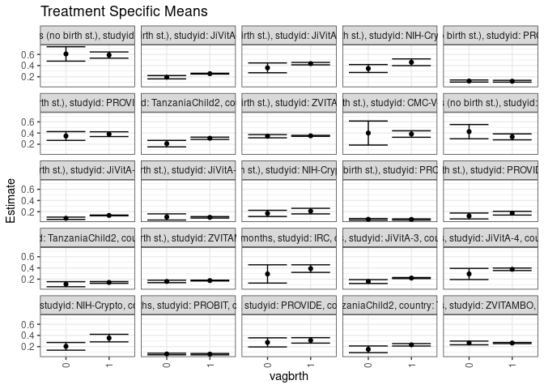

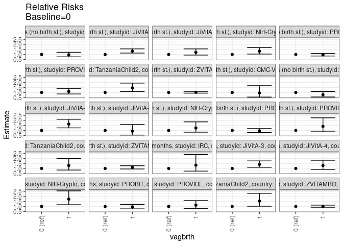

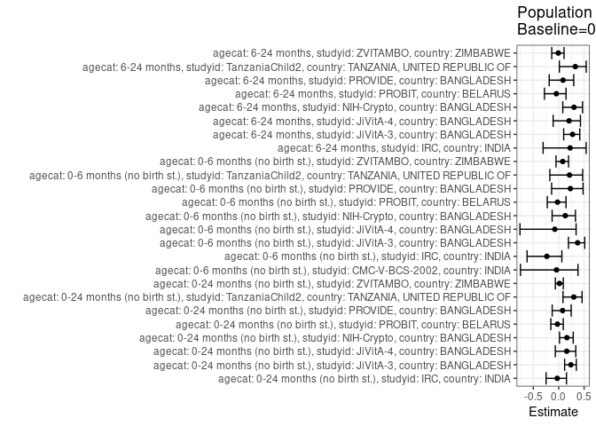

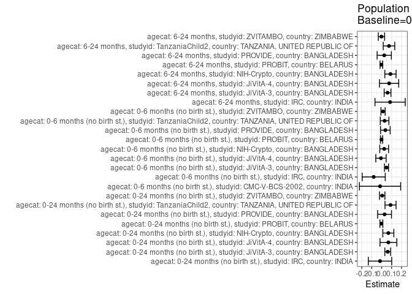

## Results Table

### Parameter: TSM

| agecat | studyid | country | intervention_level | baseline_level | estimate | ci_lower | ci_upper |
| --- | --- | --- | --- | --- | --- | --- | --- |
| 0-24 months (no birth st.) | IRC | INDIA | 0 | NA | 0.6085378 | 0.4798857 | 0.7371898 |
| 0-24 months (no birth st.) | IRC | INDIA | 1 | NA | 0.5883263 | 0.5327626 | 0.6438900 |
| 0-24 months (no birth st.) | JiVitA-3 | BANGLADESH | 0 | NA | 0.1916635 | 0.1622989 | 0.2210280 |
| 0-24 months (no birth st.) | JiVitA-3 | BANGLADESH | 1 | NA | 0.2554469 | 0.2475083 | 0.2633855 |
| 0-24 months (no birth st.) | JiVitA-4 | BANGLADESH | 0 | NA | 0.3593903 | 0.2714270 | 0.4473536 |
| 0-24 months (no birth st.) | JiVitA-4 | BANGLADESH | 1 | NA | 0.4351794 | 0.4135376 | 0.4568213 |
| 0-24 months (no birth st.) | NIH-Crypto | BANGLADESH | 0 | NA | 0.3473632 | 0.2763325 | 0.4183939 |
| 0-24 months (no birth st.) | NIH-Crypto | BANGLADESH | 1 | NA | 0.4594220 | 0.3996081 | 0.5192359 |
| 0-24 months (no birth st.) | PROBIT | BELARUS | 0 | NA | 0.1236143 | 0.1045578 | 0.1426708 |
| 0-24 months (no birth st.) | PROBIT | BELARUS | 1 | NA | 0.1202025 | 0.1038762 | 0.1365287 |
| 0-24 months (no birth st.) | PROVIDE | BANGLADESH | 0 | NA | 0.3469650 | 0.2682160 | 0.4257140 |
| 0-24 months (no birth st.) | PROVIDE | BANGLADESH | 1 | NA | 0.3798986 | 0.3374529 | 0.4223443 |
| 0-24 months (no birth st.) | TanzaniaChild2 | TANZANIA, UNITED REPUBLIC OF | 0 | NA | 0.2103784 | 0.1527828 | 0.2679739 |
| 0-24 months (no birth st.) | TanzaniaChild2 | TANZANIA, UNITED REPUBLIC OF | 1 | NA | 0.3061265 | 0.2860223 | 0.3262306 |
| 0-24 months (no birth st.) | ZVITAMBO | ZIMBABWE | 0 | NA | 0.3434185 | 0.3150670 | 0.3717699 |
| 0-24 months (no birth st.) | ZVITAMBO | ZIMBABWE | 1 | NA | 0.3501993 | 0.3414681 | 0.3589305 |
| 0-6 months (no birth st.) | CMC-V-BCS-2002 | INDIA | 0 | NA | 0.4000000 | 0.1849281 | 0.6150719 |
| 0-6 months (no birth st.) | CMC-V-BCS-2002 | INDIA | 1 | NA | 0.3823529 | 0.3245019 | 0.4402040 |
| 0-6 months (no birth st.) | IRC | INDIA | 0 | NA | 0.4248167 | 0.2973525 | 0.5522809 |
| 0-6 months (no birth st.) | IRC | INDIA | 1 | NA | 0.3316412 | 0.2783238 | 0.3849587 |
| 0-6 months (no birth st.) | JiVitA-3 | BANGLADESH | 0 | NA | 0.0816961 | 0.0606595 | 0.1027328 |
| 0-6 months (no birth st.) | JiVitA-3 | BANGLADESH | 1 | NA | 0.1332103 | 0.1274321 | 0.1389886 |
| 0-6 months (no birth st.) | JiVitA-4 | BANGLADESH | 0 | NA | 0.1053322 | 0.0502626 | 0.1604018 |
| 0-6 months (no birth st.) | JiVitA-4 | BANGLADESH | 1 | NA | 0.0980989 | 0.0851713 | 0.1110265 |
| 0-6 months (no birth st.) | NIH-Crypto | BANGLADESH | 0 | NA | 0.1692348 | 0.1139435 | 0.2245261 |
| 0-6 months (no birth st.) | NIH-Crypto | BANGLADESH | 1 | NA | 0.2101509 | 0.1602618 | 0.2600400 |
| 0-6 months (no birth st.) | PROBIT | BELARUS | 0 | NA | 0.0629051 | 0.0487008 | 0.0771094 |
| 0-6 months (no birth st.) | PROBIT | BELARUS | 1 | NA | 0.0609529 | 0.0498872 | 0.0720186 |
| 0-6 months (no birth st.) | PROVIDE | BANGLADESH | 0 | NA | 0.1229034 | 0.0700035 | 0.1758033 |
| 0-6 months (no birth st.) | PROVIDE | BANGLADESH | 1 | NA | 0.1725436 | 0.1392183 | 0.2058688 |
| 0-6 months (no birth st.) | TanzaniaChild2 | TANZANIA, UNITED REPUBLIC OF | 0 | NA | 0.1089572 | 0.0637970 | 0.1541173 |
| 0-6 months (no birth st.) | TanzaniaChild2 | TANZANIA, UNITED REPUBLIC OF | 1 | NA | 0.1410363 | 0.1258697 | 0.1562029 |
| 0-6 months (no birth st.) | ZVITAMBO | ZIMBABWE | 0 | NA | 0.1586031 | 0.1364885 | 0.1807178 |
| 0-6 months (no birth st.) | ZVITAMBO | ZIMBABWE | 1 | NA | 0.1739289 | 0.1669793 | 0.1808785 |
| 6-24 months | IRC | INDIA | 0 | NA | 0.2924035 | 0.1290169 | 0.4557900 |
| 6-24 months | IRC | INDIA | 1 | NA | 0.3881564 | 0.3205096 | 0.4558033 |
| 6-24 months | JiVitA-3 | BANGLADESH | 0 | NA | 0.1567129 | 0.1224477 | 0.1909782 |
| 6-24 months | JiVitA-3 | BANGLADESH | 1 | NA | 0.2192136 | 0.2094912 | 0.2289360 |
| 6-24 months | JiVitA-4 | BANGLADESH | 0 | NA | 0.2927421 | 0.1933668 | 0.3921173 |
| 6-24 months | JiVitA-4 | BANGLADESH | 1 | NA | 0.3756528 | 0.3535036 | 0.3978021 |
| 6-24 months | NIH-Crypto | BANGLADESH | 0 | NA | 0.2042819 | 0.1352335 | 0.2733303 |
| 6-24 months | NIH-Crypto | BANGLADESH | 1 | NA | 0.3521135 | 0.2843243 | 0.4199028 |
| 6-24 months | PROBIT | BELARUS | 0 | NA | 0.0672780 | 0.0528228 | 0.0817331 |
| 6-24 months | PROBIT | BELARUS | 1 | NA | 0.0643746 | 0.0520908 | 0.0766584 |
| 6-24 months | PROVIDE | BANGLADESH | 0 | NA | 0.2748062 | 0.1932665 | 0.3563459 |
| 6-24 months | PROVIDE | BANGLADESH | 1 | NA | 0.3106679 | 0.2619047 | 0.3594310 |
| 6-24 months | TanzaniaChild2 | TANZANIA, UNITED REPUBLIC OF | 0 | NA | 0.1510268 | 0.0911079 | 0.2109456 |
| 6-24 months | TanzaniaChild2 | TANZANIA, UNITED REPUBLIC OF | 1 | NA | 0.2317993 | 0.2099901 | 0.2536084 |
| 6-24 months | ZVITAMBO | ZIMBABWE | 0 | NA | 0.2650470 | 0.2318958 | 0.2981982 |
| 6-24 months | ZVITAMBO | ZIMBABWE | 1 | NA | 0.2634625 | 0.2536195 | 0.2733055 |

### Parameter: E(Y)

| agecat | studyid | country | intervention_level | baseline_level | estimate | ci_lower | ci_upper |
| --- | --- | --- | --- | --- | --- | --- | --- |
| 0-24 months (no birth st.) | IRC | INDIA | NA | NA | 0.5916667 | 0.5408218 | 0.6425115 |
| 0-24 months (no birth st.) | JiVitA-3 | BANGLADESH | NA | NA | 0.2522552 | 0.2445070 | 0.2600034 |
| 0-24 months (no birth st.) | JiVitA-4 | BANGLADESH | NA | NA | 0.4270574 | 0.4065290 | 0.4475857 |
| 0-24 months (no birth st.) | NIH-Crypto | BANGLADESH | NA | NA | 0.4143519 | 0.3678455 | 0.4608582 |
| 0-24 months (no birth st.) | PROBIT | BELARUS | NA | NA | 0.1205488 | 0.1047261 | 0.1363714 |
| 0-24 months (no birth st.) | PROVIDE | BANGLADESH | NA | NA | 0.3759874 | 0.3382238 | 0.4137509 |
| 0-24 months (no birth st.) | TanzaniaChild2 | TANZANIA, UNITED REPUBLIC OF | NA | NA | 0.2990485 | 0.2799429 | 0.3181541 |
| 0-24 months (no birth st.) | ZVITAMBO | ZIMBABWE | NA | NA | 0.3487442 | 0.3403900 | 0.3570984 |
| 0-6 months (no birth st.) | CMC-V-BCS-2002 | INDIA | NA | NA | 0.3835616 | 0.3276935 | 0.4394298 |
| 0-6 months (no birth st.) | IRC | INDIA | NA | NA | 0.3444444 | 0.2952897 | 0.3935992 |
| 0-6 months (no birth st.) | JiVitA-3 | BANGLADESH | NA | NA | 0.1301138 | 0.1245115 | 0.1357160 |
| 0-6 months (no birth st.) | JiVitA-4 | BANGLADESH | NA | NA | 0.0978125 | 0.0850264 | 0.1105986 |
| 0-6 months (no birth st.) | NIH-Crypto | BANGLADESH | NA | NA | 0.1944444 | 0.1570803 | 0.2318086 |
| 0-6 months (no birth st.) | PROBIT | BELARUS | NA | NA | 0.0614448 | 0.0507274 | 0.0721623 |
| 0-6 months (no birth st.) | PROVIDE | BANGLADESH | NA | NA | 0.1595577 | 0.1310079 | 0.1881074 |
| 0-6 months (no birth st.) | TanzaniaChild2 | TANZANIA, UNITED REPUBLIC OF | NA | NA | 0.1381966 | 0.1237955 | 0.1525978 |
| 0-6 months (no birth st.) | ZVITAMBO | ZIMBABWE | NA | NA | 0.1721902 | 0.1655693 | 0.1788111 |
| 6-24 months | IRC | INDIA | NA | NA | 0.3771186 | 0.3151523 | 0.4390850 |
| 6-24 months | JiVitA-3 | BANGLADESH | NA | NA | 0.2156694 | 0.2063399 | 0.2249988 |
| 6-24 months | JiVitA-4 | BANGLADESH | NA | NA | 0.3674386 | 0.3465522 | 0.3883251 |
| 6-24 months | NIH-Crypto | BANGLADESH | NA | NA | 0.2923077 | 0.2427834 | 0.3418319 |
| 6-24 months | PROBIT | BELARUS | NA | NA | 0.0642659 | 0.0526827 | 0.0758490 |
| 6-24 months | PROVIDE | BANGLADESH | NA | NA | 0.3004386 | 0.2583143 | 0.3425629 |
| 6-24 months | TanzaniaChild2 | TANZANIA, UNITED REPUBLIC OF | NA | NA | 0.2243995 | 0.2038353 | 0.2449637 |
| 6-24 months | ZVITAMBO | ZIMBABWE | NA | NA | 0.2627521 | 0.2533561 | 0.2721480 |

### Parameter: RR

| agecat | studyid | country | intervention_level | baseline_level | estimate | ci_lower | ci_upper |
| --- | --- | --- | --- | --- | --- | --- | --- |
| 0-24 months (no birth st.) | IRC | INDIA | 0 | 0 | 1.0000000 | 1.0000000 | 1.000000 |
| 0-24 months (no birth st.) | IRC | INDIA | 1 | 0 | 0.9667868 | 0.7670556 | 1.218525 |
| 0-24 months (no birth st.) | JiVitA-3 | BANGLADESH | 0 | 0 | 1.0000000 | 1.0000000 | 1.000000 |
| 0-24 months (no birth st.) | JiVitA-3 | BANGLADESH | 1 | 0 | 1.3327887 | 1.1413083 | 1.556394 |
| 0-24 months (no birth st.) | JiVitA-4 | BANGLADESH | 0 | 0 | 1.0000000 | 1.0000000 | 1.000000 |
| 0-24 months (no birth st.) | JiVitA-4 | BANGLADESH | 1 | 0 | 1.2108825 | 0.9434684 | 1.554092 |
| 0-24 months (no birth st.) | NIH-Crypto | BANGLADESH | 0 | 0 | 1.0000000 | 1.0000000 | 1.000000 |
| 0-24 months (no birth st.) | NIH-Crypto | BANGLADESH | 1 | 0 | 1.3225985 | 1.0423402 | 1.678211 |
| 0-24 months (no birth st.) | PROBIT | BELARUS | 0 | 0 | 1.0000000 | 1.0000000 | 1.000000 |
| 0-24 months (no birth st.) | PROBIT | BELARUS | 1 | 0 | 0.9723990 | 0.8514709 | 1.110502 |
| 0-24 months (no birth st.) | PROVIDE | BANGLADESH | 0 | 0 | 1.0000000 | 1.0000000 | 1.000000 |
| 0-24 months (no birth st.) | PROVIDE | BANGLADESH | 1 | 0 | 1.0949191 | 0.8521604 | 1.406834 |
| 0-24 months (no birth st.) | TanzaniaChild2 | TANZANIA, UNITED REPUBLIC OF | 0 | 0 | 1.0000000 | 1.0000000 | 1.000000 |
| 0-24 months (no birth st.) | TanzaniaChild2 | TANZANIA, UNITED REPUBLIC OF | 1 | 0 | 1.4551234 | 1.0987303 | 1.927119 |
| 0-24 months (no birth st.) | ZVITAMBO | ZIMBABWE | 0 | 0 | 1.0000000 | 1.0000000 | 1.000000 |
| 0-24 months (no birth st.) | ZVITAMBO | ZIMBABWE | 1 | 0 | 1.0197453 | 0.9358909 | 1.111113 |
| 0-6 months (no birth st.) | CMC-V-BCS-2002 | INDIA | 0 | 0 | 1.0000000 | 1.0000000 | 1.000000 |
| 0-6 months (no birth st.) | CMC-V-BCS-2002 | INDIA | 1 | 0 | 0.9558824 | 0.5467942 | 1.671033 |
| 0-6 months (no birth st.) | IRC | INDIA | 0 | 0 | 1.0000000 | 1.0000000 | 1.000000 |
| 0-6 months (no birth st.) | IRC | INDIA | 1 | 0 | 0.7806690 | 0.5552231 | 1.097656 |
| 0-6 months (no birth st.) | JiVitA-3 | BANGLADESH | 0 | 0 | 1.0000000 | 1.0000000 | 1.000000 |
| 0-6 months (no birth st.) | JiVitA-3 | BANGLADESH | 1 | 0 | 1.6305585 | 1.2585578 | 2.112514 |
| 0-6 months (no birth st.) | JiVitA-4 | BANGLADESH | 0 | 0 | 1.0000000 | 1.0000000 | 1.000000 |
| 0-6 months (no birth st.) | JiVitA-4 | BANGLADESH | 1 | 0 | 0.9313288 | 0.5448111 | 1.592062 |
| 0-6 months (no birth st.) | NIH-Crypto | BANGLADESH | 0 | 0 | 1.0000000 | 1.0000000 | 1.000000 |
| 0-6 months (no birth st.) | NIH-Crypto | BANGLADESH | 1 | 0 | 1.2417709 | 0.8317581 | 1.853898 |
| 0-6 months (no birth st.) | PROBIT | BELARUS | 0 | 0 | 1.0000000 | 1.0000000 | 1.000000 |
| 0-6 months (no birth st.) | PROBIT | BELARUS | 1 | 0 | 0.9689661 | 0.7934196 | 1.183353 |
| 0-6 months (no birth st.) | PROVIDE | BANGLADESH | 0 | 0 | 1.0000000 | 1.0000000 | 1.000000 |
| 0-6 months (no birth st.) | PROVIDE | BANGLADESH | 1 | 0 | 1.4038960 | 0.8755359 | 2.251106 |
| 0-6 months (no birth st.) | TanzaniaChild2 | TANZANIA, UNITED REPUBLIC OF | 0 | 0 | 1.0000000 | 1.0000000 | 1.000000 |
| 0-6 months (no birth st.) | TanzaniaChild2 | TANZANIA, UNITED REPUBLIC OF | 1 | 0 | 1.2944198 | 0.8441641 | 1.984831 |
| 0-6 months (no birth st.) | ZVITAMBO | ZIMBABWE | 0 | 0 | 1.0000000 | 1.0000000 | 1.000000 |
| 0-6 months (no birth st.) | ZVITAMBO | ZIMBABWE | 1 | 0 | 1.0966293 | 0.9489348 | 1.267311 |
| 6-24 months | IRC | INDIA | 0 | 0 | 1.0000000 | 1.0000000 | 1.000000 |
| 6-24 months | IRC | INDIA | 1 | 0 | 1.3274685 | 0.7392367 | 2.383773 |
| 6-24 months | JiVitA-3 | BANGLADESH | 0 | 0 | 1.0000000 | 1.0000000 | 1.000000 |
| 6-24 months | JiVitA-3 | BANGLADESH | 1 | 0 | 1.3988226 | 1.1193056 | 1.748142 |
| 6-24 months | JiVitA-4 | BANGLADESH | 0 | 0 | 1.0000000 | 1.0000000 | 1.000000 |
| 6-24 months | JiVitA-4 | BANGLADESH | 1 | 0 | 1.2832213 | 0.9088299 | 1.811843 |
| 6-24 months | NIH-Crypto | BANGLADESH | 0 | 0 | 1.0000000 | 1.0000000 | 1.000000 |
| 6-24 months | NIH-Crypto | BANGLADESH | 1 | 0 | 1.7236649 | 1.1697301 | 2.539920 |
| 6-24 months | PROBIT | BELARUS | 0 | 0 | 1.0000000 | 1.0000000 | 1.000000 |
| 6-24 months | PROBIT | BELARUS | 1 | 0 | 0.9568448 | 0.7628430 | 1.200184 |
| 6-24 months | PROVIDE | BANGLADESH | 0 | 0 | 1.0000000 | 1.0000000 | 1.000000 |
| 6-24 months | PROVIDE | BANGLADESH | 1 | 0 | 1.1304980 | 0.8098649 | 1.578073 |
| 6-24 months | TanzaniaChild2 | TANZANIA, UNITED REPUBLIC OF | 0 | 0 | 1.0000000 | 1.0000000 | 1.000000 |
| 6-24 months | TanzaniaChild2 | TANZANIA, UNITED REPUBLIC OF | 1 | 0 | 1.5348222 | 1.0216364 | 2.305790 |
| 6-24 months | ZVITAMBO | ZIMBABWE | 0 | 0 | 1.0000000 | 1.0000000 | 1.000000 |
| 6-24 months | ZVITAMBO | ZIMBABWE | 1 | 0 | 0.9940219 | 0.8726087 | 1.132328 |

### Parameter: PAR

| agecat | studyid | country | intervention_level | baseline_level | estimate | ci_lower | ci_upper |
| --- | --- | --- | --- | --- | --- | --- | --- |
| 0-24 months (no birth st.) | IRC | INDIA | 0 | NA | -0.0168711 | -0.1347876 | 0.1010454 |
| 0-24 months (no birth st.) | JiVitA-3 | BANGLADESH | 0 | NA | 0.0605918 | 0.0316339 | 0.0895496 |
| 0-24 months (no birth st.) | JiVitA-4 | BANGLADESH | 0 | NA | 0.0676671 | -0.0171061 | 0.1524403 |
| 0-24 months (no birth st.) | NIH-Crypto | BANGLADESH | 0 | NA | 0.0669887 | 0.0115491 | 0.1224282 |
| 0-24 months (no birth st.) | PROBIT | BELARUS | 0 | NA | -0.0030656 | -0.0176741 | 0.0115430 |
| 0-24 months (no birth st.) | PROVIDE | BANGLADESH | 0 | NA | 0.0290224 | -0.0406775 | 0.0987222 |
| 0-24 months (no birth st.) | TanzaniaChild2 | TANZANIA, UNITED REPUBLIC OF | 0 | NA | 0.0886701 | 0.0331119 | 0.1442284 |
| 0-24 months (no birth st.) | ZVITAMBO | ZIMBABWE | 0 | NA | 0.0053257 | -0.0217828 | 0.0324343 |
| 0-6 months (no birth st.) | CMC-V-BCS-2002 | INDIA | 0 | NA | -0.0164384 | -0.2239010 | 0.1910243 |
| 0-6 months (no birth st.) | IRC | INDIA | 0 | NA | -0.0803722 | -0.1964829 | 0.0357384 |
| 0-6 months (no birth st.) | JiVitA-3 | BANGLADESH | 0 | NA | 0.0484176 | 0.0277325 | 0.0691027 |
| 0-6 months (no birth st.) | JiVitA-4 | BANGLADESH | 0 | NA | -0.0075197 | -0.0594981 | 0.0444587 |
| 0-6 months (no birth st.) | NIH-Crypto | BANGLADESH | 0 | NA | 0.0252096 | -0.0191000 | 0.0695192 |
| 0-6 months (no birth st.) | PROBIT | BELARUS | 0 | NA | -0.0014602 | -0.0126652 | 0.0097448 |
| 0-6 months (no birth st.) | PROVIDE | BANGLADESH | 0 | NA | 0.0366543 | -0.0119082 | 0.0852167 |
| 0-6 months (no birth st.) | TanzaniaChild2 | TANZANIA, UNITED REPUBLIC OF | 0 | NA | 0.0292395 | -0.0141958 | 0.0726747 |
| 0-6 months (no birth st.) | ZVITAMBO | ZIMBABWE | 0 | NA | 0.0135871 | -0.0076093 | 0.0347834 |
| 6-24 months | IRC | INDIA | 0 | NA | 0.0847152 | -0.0674583 | 0.2368886 |
| 6-24 months | JiVitA-3 | BANGLADESH | 0 | NA | 0.0589564 | 0.0248710 | 0.0930419 |
| 6-24 months | JiVitA-4 | BANGLADESH | 0 | NA | 0.0746966 | -0.0220406 | 0.1714338 |
| 6-24 months | NIH-Crypto | BANGLADESH | 0 | NA | 0.0880258 | 0.0315561 | 0.1444956 |
| 6-24 months | PROBIT | BELARUS | 0 | NA | -0.0030121 | -0.0164088 | 0.0103846 |
| 6-24 months | PROVIDE | BANGLADESH | 0 | NA | 0.0256324 | -0.0460091 | 0.0972739 |
| 6-24 months | TanzaniaChild2 | TANZANIA, UNITED REPUBLIC OF | 0 | NA | 0.0733727 | 0.0154238 | 0.1313216 |
| 6-24 months | ZVITAMBO | ZIMBABWE | 0 | NA | -0.0022949 | -0.0340340 | 0.0294442 |

### Parameter: PAF

| agecat | studyid | country | intervention_level | baseline_level | estimate | ci_lower | ci_upper |
| --- | --- | --- | --- | --- | --- | --- | --- |
| 0-24 months (no birth st.) | IRC | INDIA | 0 | NA | -0.0285145 | -0.2484318 | 0.1526632 |
| 0-24 months (no birth st.) | JiVitA-3 | BANGLADESH | 0 | NA | 0.2402002 | 0.1166978 | 0.3464346 |
| 0-24 months (no birth st.) | JiVitA-4 | BANGLADESH | 0 | NA | 0.1584496 | -0.0659660 | 0.3356195 |
| 0-24 months (no birth st.) | NIH-Crypto | BANGLADESH | 0 | NA | 0.1616710 | 0.0159504 | 0.2858129 |
| 0-24 months (no birth st.) | PROBIT | BELARUS | 0 | NA | -0.0254301 | -0.1549318 | 0.0895506 |
| 0-24 months (no birth st.) | PROVIDE | BANGLADESH | 0 | NA | 0.0771898 | -0.1281694 | 0.2451677 |
| 0-24 months (no birth st.) | TanzaniaChild2 | TANZANIA, UNITED REPUBLIC OF | 0 | NA | 0.2965075 | 0.0841879 | 0.4596035 |
| 0-24 months (no birth st.) | ZVITAMBO | ZIMBABWE | 0 | NA | 0.0152712 | -0.0656113 | 0.0900145 |
| 0-6 months (no birth st.) | CMC-V-BCS-2002 | INDIA | 0 | NA | -0.0428571 | -0.7517776 | 0.3791729 |
| 0-6 months (no birth st.) | IRC | INDIA | 0 | NA | -0.2333388 | -0.6218239 | 0.0620902 |
| 0-6 months (no birth st.) | JiVitA-3 | BANGLADESH | 0 | NA | 0.3721175 | 0.1916514 | 0.5122941 |
| 0-6 months (no birth st.) | JiVitA-4 | BANGLADESH | 0 | NA | -0.0768784 | -0.7619998 | 0.3418460 |
| 0-6 months (no birth st.) | NIH-Crypto | BANGLADESH | 0 | NA | 0.1296494 | -0.1296560 | 0.3294329 |
| 0-6 months (no birth st.) | PROBIT | BELARUS | 0 | NA | -0.0237649 | -0.2242258 | 0.1438716 |
| 0-6 months (no birth st.) | PROVIDE | BANGLADESH | 0 | NA | 0.2297244 | -0.1393868 | 0.4792597 |
| 0-6 months (no birth st.) | TanzaniaChild2 | TANZANIA, UNITED REPUBLIC OF | 0 | NA | 0.2115788 | -0.1743127 | 0.4706623 |
| 0-6 months (no birth st.) | ZVITAMBO | ZIMBABWE | 0 | NA | 0.0789072 | -0.0527884 | 0.1941287 |
| 6-24 months | IRC | INDIA | 0 | NA | 0.2246379 | -0.3065789 | 0.5398775 |
| 6-24 months | JiVitA-3 | BANGLADESH | 0 | NA | 0.2733649 | 0.0979958 | 0.4146385 |
| 6-24 months | JiVitA-4 | BANGLADESH | 0 | NA | 0.2032900 | -0.1093745 | 0.4278336 |
| 6-24 months | NIH-Crypto | BANGLADESH | 0 | NA | 0.3011409 | 0.0802433 | 0.4689856 |
| 6-24 months | PROBIT | BELARUS | 0 | NA | -0.0468695 | -0.2811965 | 0.1445997 |
| 6-24 months | PROVIDE | BANGLADESH | 0 | NA | 0.0853166 | -0.1868342 | 0.2950610 |
| 6-24 months | TanzaniaChild2 | TANZANIA, UNITED REPUBLIC OF | 0 | NA | 0.3269736 | 0.0131643 | 0.5409930 |
| 6-24 months | ZVITAMBO | ZIMBABWE | 0 | NA | -0.0087341 | -0.1370574 | 0.1051072 |